# Repro Research Course Project 1

Hongyu Shen

2016年3月6日

## Introduction

This assignment is the first peer assessment of coursera Reproducible Research course.

#### First is to load basic packages.

```r
library(ggplot2)
```

Then is to load the data got forom the GitHub repository. The file should be unzipped and in the same folder as the working directory.

```r
data<-read.csv("activity.csv",na.strings = "NA")
```

#### Mean total number of steps taken per day.

Find the sum of the number of steps taken per day.And also remove the NA.

```r
sum_steps <- aggregate(data$steps, by=list(data$date), FUN=sum, na.rm=TRUE)
names(sum_steps)<-c("date","steps")
head(sum_steps)
```

```
##         date steps
## 1 2012-10-01     0
## 2 2012-10-02   126
## 3 2012-10-03 11352
## 4 2012-10-04 12116
## 5 2012-10-05 13294
## 6 2012-10-06 15420
```

Plot the histogram

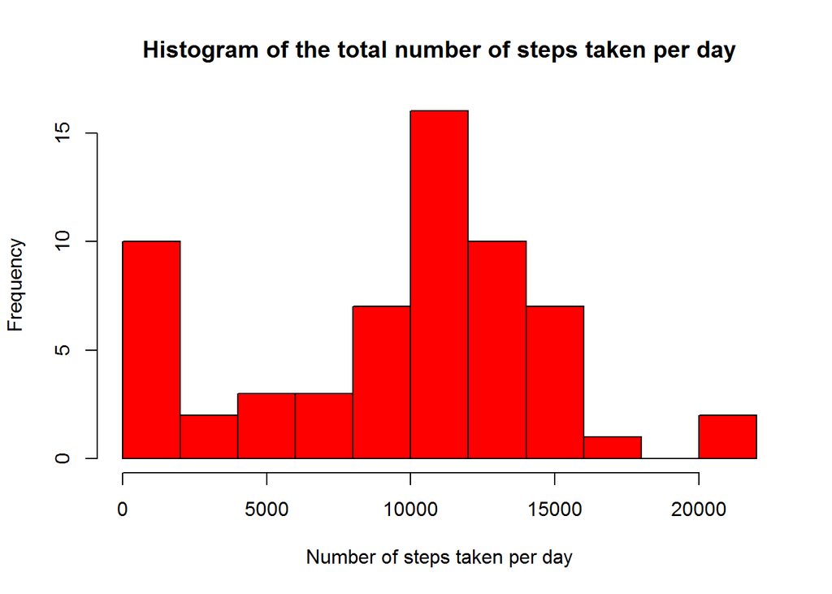

```r
hist(sum_steps$steps,breaks=8,main="Histogram of the total number of steps taken per day",xlab = "Number of steps taken per day",ylab = "Frequency",col="red")
```

Then the mean and median of the total number of steps taken per day:

```r
mean(sum_steps$steps)
```

```
## [1] 9354.23
```

```r
median(sum_steps$steps)
```

```
## [1] 10395
```

The mean of the steps taken per day is 9354 and the median of the steps taken per day is 10395

#### The average daily activity pattern

First is to aggregate a new data sets

```r
ave_steps <- aggregate(data$steps, by=list(data$interval), FUN=sum, na.rm=TRUE)
names(ave_steps)<-c("interval","steps")
head(ave_steps)
```

```
##   interval steps
## 1        0    91
## 2        5    18
## 3       10     7
## 4       15     8
## 5       20     4
## 6       25   111
```

Plot the graph

[figure not shown]

```r
plot(ave_steps$interval,ave_steps$steps,type="l",xlab = "5-min interval",ylab="the average number of stepps", main="average daily activity pattern")
```

Which 5-minute interval, on average across all the days in the dataset, contains the maximum number of steps?

```r
# find the position of the max
max_pos <- which(ave_steps$steps == max(ave_steps$steps))
max_interval<-ave_steps[max_pos,1]
```

And it turns out that 835 5-min interval, contains the maximum number of steps.

#### Inputing the missing values

Calculate and report the total number of missing values in the dataset (i.e. the total number of rows with NAs)

```r
sum(is.na(data))
```

```
## [1] 2304
```

And the number of NA is 2304.

Devise a strategy for filling in all of the missing values in the dataset. The strategy does not need to be sophisticated. For example, you could use the mean/median for that day, or the mean for that 5-minute interval, etc.

Find the NA postion and find the means

```r
na_pos<-which(is.na(data$steps))
mean_vec <- rep(mean(data$steps, na.rm=TRUE), times=length(na_pos))
```

Create a new dataset that is equal to the original dataset but with the missing data filled in.

```r
data[na_pos,"steps"]<-mean_vec
head(data)
```

```
##     steps       date interval
## 1 37.3826 2012-10-01        0
## 2 37.3826 2012-10-01        5
## 3 37.3826 2012-10-01       10
## 4 37.3826 2012-10-01       15
## 5 37.3826 2012-10-01       20
## 6 37.3826 2012-10-01       25
```

```r
sum_steps <- aggregate(data$steps, by=list(data$date), FUN=sum, na.rm=TRUE)
names(sum_steps)<-c("date","steps")
head(sum_steps)
```

```
##         date    steps
## 1 2012-10-01 10766.19
## 2 2012-10-02   126.00
## 3 2012-10-03 11352.00
## 4 2012-10-04 12116.00
## 5 2012-10-05 13294.00
## 6 2012-10-06 15420.00
```

Plot the histogram

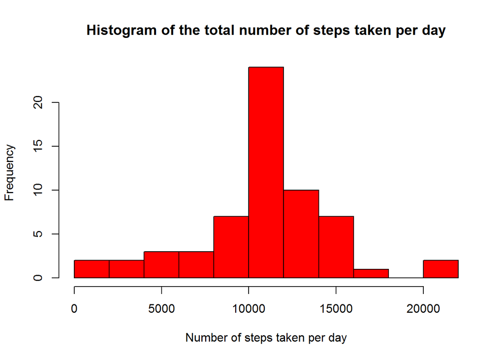

```r
hist(sum_steps$steps,breaks=8,main="Histogram of the total number of steps taken per day",xlab = "Number of steps taken per day",ylab = "Frequency",col="red")
```

#### Are there differences in activity patterns between weekdays and weekends?

First is to convert the date to factor and then apply weekdays()

```r
data$date<-as.POSIXct(data$date,format="%Y-%m-%d")
data<-data.frame(data,weekdays=weekdays(data$date))
levels(data$weekdays)
```

```
## [1] "Friday"    "Monday"    "Saturday"  "Sunday"    "Thursday"  "Tuesday"
## [7] "Wednesday"
```

From the levels, we can see that the weekdays are presented this form, then I converted Monday to Friday to weekdays.

```r
levels(data$weekdays)<-list(weekday = c("Monday", "Tuesday", "Wednesday",  "Thursday", "Friday"),weekend = c("Saturday", "Sunday"))
```

Make a panel plot containing a time series plot (i.e. type = “l”) of the 5-minute interval (x-axis) and the average number of steps taken, averaged across all weekday days or weekend days (y-axis).

```r
mean_data <- aggregate(data$steps, by=list( data$weekday, data$interval), mean)
names(mean_data) <- c("weekday", "interval", "mean")
head(mean_data)
```

```
##   weekday interval     mean
## 1 weekday        0 7.006569
## 2 weekend        0 4.672825
## 3 weekday        5 5.384347
## 4 weekend        5 4.672825
## 5 weekday       10 5.139902
## 6 weekend       10 4.672825
```

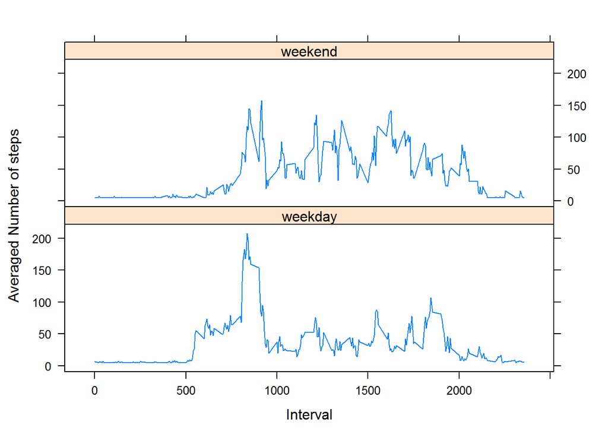

```r
library(lattice)
xyplot(mean ~ interval | weekday, mean_data, type="l",lwd=1,xlab="Interval",ylab="Averaged Number of steps",layout=c(1,2))
```

[output not shown]